# Opioid Abuse Risk and Services Provision

Kyle McCarthy and Tristan Grupp

12/15/2020

# Introduction

Heroin Overdoses are an epidemic across the United States. In the United States, there are over 60,000 opioid overdose-related deaths each year. There are two approaches a city can take to minimize heroin overdose death rates. First, they can provide more significant social services for those struggling with heroin addiction. Social services include both rehab centers and addiction support centers. Rehab centers typically help those struggling to get off drugs. Addiction support centers, similar to Alcoholics Anonymous, provide a support group for those who have experienced opioid addiction. Support groups often ensure that former drug addicts do not retake heroin or other substances. Cities can also provide clean needle exchange to reduce the spread of disease from sharing needles. Secondly, cities can provide greater EMS services to prevent opioid-related deaths. An EMS team’s optimal response time when someone goes unconscious from an opioid overdose is 4-6 minutes. This short, but necessary response time, is a significant factor in preventing heroin overdose deaths where heroin overdoses pose a considerable threat. Consequently, it is essential that cities strategically place their EMS units near opioid deaths occur.

Finally, and most importantly, the model’s main purpose is to identify where to locate resources, including EMS services and opioid resource centers/community support centers. To understand where EMS services should be placed, begin by selecting regions that our model has predicted to be a high risk of heroin overdoses. Secondly, we look at where the EMS delays are the longest by taking the mean of delay time in each fishnet grid cell, which is calculated by subtracting the EMS call time from EMS arrival time. According to the CDC, any response time greater than 6 minutes is considered too long. Selected areas are buffered 1 mile and vacant lots are located within the selected region. To understand where social services are needed, rehab and support services are buffered with a 2-mile radius. Any high-risk grid cell outside of those buffers is considered a high-risk, underserved region. Those grid cells are buffered 1 mile, and vacant lots are located within the recommended buffer region.

[Presentation Video](https://www.youtube.com/watch?v=mM-kaYQsX7k)

```r
knitr::opts_chunk$set(echo=TRUE)

# SET UP

library(tidyverse)
library(sf)
library(RSocrata)
library(viridis)
library(spatstat)
library(raster)
library(spdep)
library(FNN)
library(grid)
library(knitr)
library(kableExtra)
library(tidycensus)
library(cowplot)
library(RColorBrewer)
library(tidyverse)
library(sf)
library(lubridate)
library(tigris)
library(gganimate)
library(riem)
library(gridExtra)
library(knitr)
library(kableExtra)
palette2 <- c("#6baed6","#08519c")

root.dir = "https://raw.githubusercontent.com/urbanSpatial/Public-Policy-Analytics-Landing/master/DATA/"
root.dir = "https://raw.githubusercontent.com/urbanSpatial/Public-Policy-Analytics-Landing/master/DATA/"
source("https://raw.githubusercontent.com/urbanSpatial/Public-Policy-Analytics-Landing/master/functions.r")
source("https://raw.githubusercontent.com/urbanSpatial/Public-Policy-Analytics-Landing/master/functions.r")
```

# Exploratory Analysis

```r
#Heroin overdose data and Cincinatti boundary

cincinnati <-
  st_read("https://opendata.arcgis.com/datasets/ed78f4754b044ac5815d0a9efe9bb336_1.geojson")%>%
  st_transform('ESRI:102323')
df <- read.socrata(
  "https://data.cincinnati-oh.gov/resource/vnsz-a3wp.json")
```

To best account for the spatial distribution of heroin overdoses, a fishnet was created. The fishnet is used to count the number of heroin overdoses in equally-sized grid cells, treating occurrences of overdoses as an event that can occur across a surface rather than summed in arbitrary boundaries such as census tracts. Here a fishnet is created, utilizing a cell size of 500 meters by 500 meters. Fishnets are utilized to aggregate the count of points to a lattice of grid cells. Fishnets are essential to represent that heroin overdose dissipates outward from hotspots, or where high counts of heroin overdoses occur.

```r
fishnet <-
  st_make_grid(cincinnati, cellsize = 500) %>%
  st_sf() %>%
  mutate(uniqueID = rownames(.))
```

[figure not shown]

```r
Hero <-
  df%>%
  filter(grepl("HERO", incident_type_desc)) %>%
  filter(grepl("2016", create_time_incident))%>%
  mutate(X = as.numeric(longitude_x),Y = as.numeric(latitude_x))%>%
  dplyr::select("X", "Y", "event_number")%>%
  na.omit()%>%
  st_as_sf(coords = c("X", "Y"), crs = 4326, agr = "constant")%>%
  st_transform('ESRI:102323')%>%
  left_join(df, by = "event_number")


Hero <-
  Hero %>%
  mutate(interval60 = floor_date(ymd_hms(dispatch_time_primary_unit), unit = "hour"),
         interval15 = floor_date(ymd_hms(dispatch_time_primary_unit), unit = "15 mins"),
         week = week(interval60),
         dotw = wday(interval60, label=TRUE))%>%
  filter( week > 23)



# TIme
Hero1 <-
  Hero %>%
  mutate(interval60 = floor_date(ymd_hms(dispatch_time_primary_unit), unit = "hour"),
         interval15 = floor_date(ymd_hms(dispatch_time_primary_unit), unit = "15 mins"),
         week = week(interval60),
         dotw = wday(interval60, label=TRUE))%>%
  filter( week > 23 & week <= 37)

Hero2 <-
  Hero %>%
  mutate(interval60 = floor_date(ymd_hms(dispatch_time_primary_unit), unit = "hour"),
         interval15 = floor_date(ymd_hms(dispatch_time_primary_unit), unit = "15 mins"),
         week = week(interval60),
         dotw = wday(interval60, label=TRUE))%>%
  filter(week > 37)



grid.arrange(ncol=2,
             top=textGrob("Heroin Overdoses, Cincinnati June 6- December 31, 2016",gp=gpar(fontsize=15,font=3)),
             ggplot() +
               geom_sf(data = cincinnati) +
               geom_sf(data = Hero, colour="purple", size=0.1, show.legend = "point") +
               labs(title= "Heroin Overdoses, Cincinnati - 2018") +
               mapTheme()+ theme(plot.title = element_text(size = 10, hjust = 0.5, face = "bold")),

             ggplot() +
               geom_sf(data = cincinnati, fill = "grey75") +
               stat_density2d(data = data.frame(st_coordinates(Hero)),
                              aes(X, Y, fill = ..level.., alpha = ..level..),
                              size = 0.01, bins = 40, geom = 'polygon') +
               scale_fill_viridis()+
               scale_alpha(range = c(0.00, 0.35), guide = FALSE) +
               labs(title = "Density of Heroin Overdoses") +
               mapTheme() + theme(legend.position = "none", plot.title = element_text(size = 10, hjust = 0.5, face = "bold")))
```

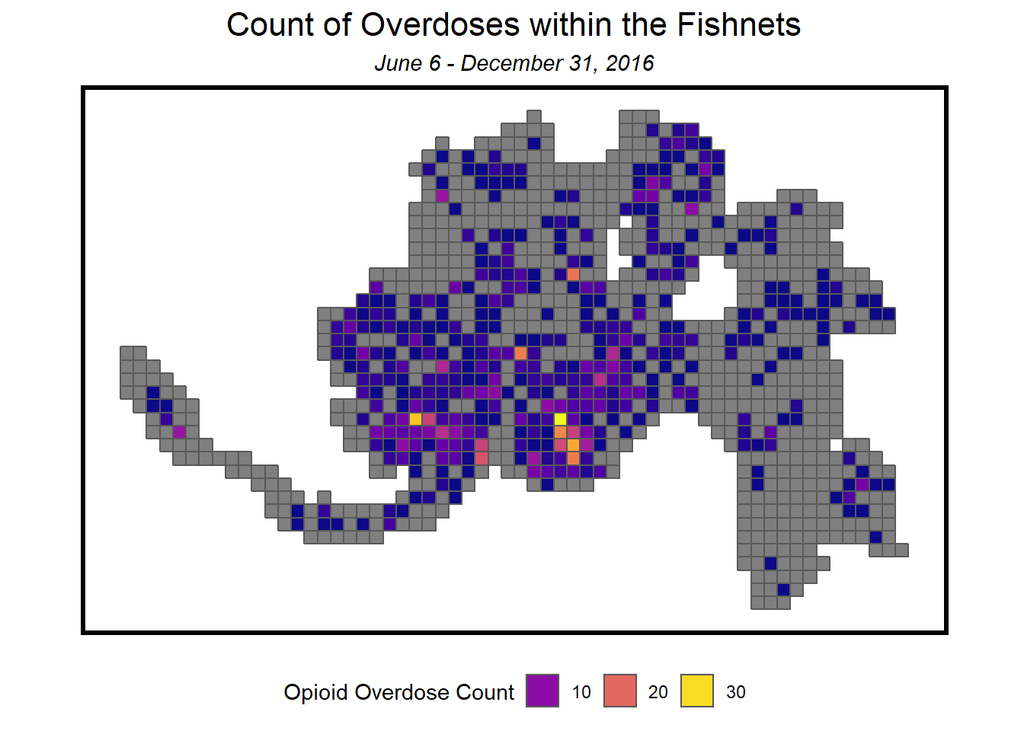

```r
Hero_net <-
  dplyr::select(Hero) %>%
  mutate(countOpioid = 1) %>%
  aggregate(., fishnet, sum) %>%
  mutate(countHero = replace_na(countOpioid, 0),
         uniqueID = rownames(.),
         cvID = sample(round(nrow(fishnet) / 6), size=nrow(fishnet), replace = TRUE))

  Hero_time1 <-
  Hero1 %>%
  dplyr::select(interval60)%>%
  mutate(Legend = "Training Set")%>%
  st_join(Hero_net)

  Hero_time2 <-
  Hero2 %>%
  dplyr::select(interval60)%>%
  mutate(Legend = "Test Set")%>%
  st_join(Hero_net)


week.panel <-
  expand.grid(
    interval15 = unique(Hero$interval60),
    uniqueID = unique(Hero_net$uniqueID))%>%
  sample_n(80000)

Hero_net1 <-
  dplyr::select(Hero1) %>%
  mutate(countOpioid = 1) %>%
  aggregate(., fishnet, sum) %>%
  mutate(countHero = replace_na(countOpioid, 0),
         uniqueID = rownames(.),
         cvID = sample(round(nrow(fishnet) / 6), size=nrow(fishnet), replace = TRUE))

Hero_net2 <-
  dplyr::select(Hero2) %>%
  mutate(countOpioid = 1) %>%
  aggregate(., fishnet, sum) %>%
  mutate(countHero = replace_na(countOpioid, 0),
         uniqueID = rownames(.),
         cvID = sample(round(nrow(fishnet) / 6), size=nrow(fishnet), replace = TRUE))

ggplot() +
  geom_sf(data = Hero_net, aes(fill = countOpioid)) +
  scale_fill_viridis(option = "plasma") +
  labs(title = "Count of Overdoses within the Fishnets", subtitle = "June 6 - December 31, 2016") +
  guides(fill=guide_legend(title="Opioid Overdose Count"))+
  mapTheme() + theme(plot.title = element_text(hjust = 0.5), legend.position = "bottom",
                     plot.subtitle = element_text(hjust = 0.5))
```

The following code displays the variables and feature engineering performed. The variables utilized were pharmacy locations, collected from various online sources, traffic, public buildings, bus stops, neighborhood central business district locations, foreclosures, shootings, assaults, theft, vandalism, and burglary. Additionally, to account for spatial processes, we downloaded neighborhoods and census variables such as median household income, male population, and poverty. Many of these variables, such as traffic and bus stops, seem unrelated to heroin overdoses. The figure below this set of code helps explains why these variables are included. As depicted, downtown regions or higher populations tend to have higher counts of heroin overdoses on average than areas away from downtown. Consequently, we included traffic, central business district location, and bus stops to account for density in downtown areas. Note that CBD was also significantly feature engineered. The CBD variable represents fishnet grid cells where the fishnet grid cell centroid intersects with a central business district polygon.

```r
Pharm <- read.csv("C:/Users/Tristan/Desktop/Penn/MUSA508 - Public Policy Analysis/final/CincyPharmacies.csv")%>%
  mutate(X = as.numeric(Longitude),Y = as.numeric(Latitude), Legend = "Pharmacy")%>%
  dplyr:: select("X", "Y", "Legend")%>%
  na.omit()%>%
  st_as_sf(coords = c("X", "Y"), crs = 4326, agr = "constant")%>%
  st_transform('ESRI:102323')%>%
  dplyr::select("Legend")%>%
  unique()

Traffic <- read.socrata("https://data.cincinnati-oh.gov/resource/rvmt-pkmq.json")
Traffic<-
  Traffic%>%
  filter(grepl("2018", crashdate))%>%
  mutate(X = as.numeric(longitude_x),Y = as.numeric(latitude_x), Legend = "Traffic")%>%
  dplyr:: select("X", "Y", "Legend")%>%
  na.omit()%>%
  st_as_sf(coords = c("X", "Y"), crs = 4326, agr = "constant")%>%
  st_transform('ESRI:102323')

Traffic<-
  Traffic%>%
  mutate(Legend = "Traffic")


# Publicly owned buildings

Public <-
  st_read("https://opendata.arcgis.com/datasets/69ed545ab456435496c3d52db13f06af_0.geojson")%>%
  st_zm()%>%
  st_as_sf()%>%
  st_transform('ESRI:102323')%>%
  mutate(Legend = "Public")%>%
  dplyr::select("Legend")%>%
  st_centroid()
# Bus

bus <-
  st_read("https://opendata.arcgis.com/datasets/e2bfcf84442f4ae5be46208f95b49942_1.geojson")%>%
  st_transform('ESRI:102323')%>%
  mutate(Legend = "Bus")%>%
  dplyr::select("Legend")
```

```
## replacing null geometries with empty geometries
## Simple feature collection with 25980 features and 21 fields (with 2 geometries empty)
## geometry type:  POINT
## dimension:      XY
## bbox:           xmin: -84.79203 ymin: 39.0726 xmax: -84.27302 ymax: 39.35641
## geographic CRS: WGS 84
```

```r
#Central Business Districts

cbd <-
  st_read("https://opendata.arcgis.com/datasets/0fa9e54fc1dd465886c3a5d980a97955_11.geojson")%>%
  st_transform('ESRI:102323')
```

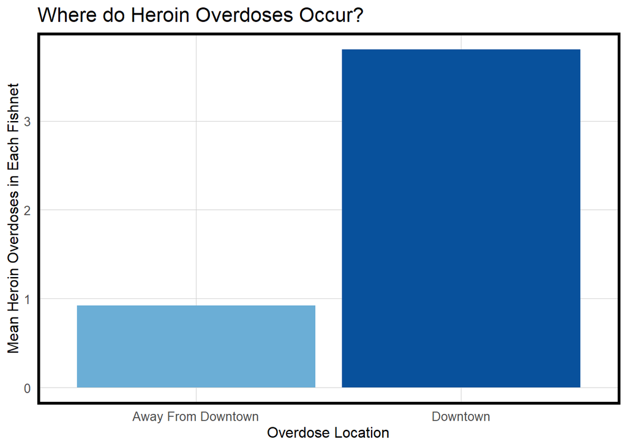

```r
cbd <-
  st_centroid(fishnet) %>%
  st_join(dplyr::select(cbd, DIS_NAME)) %>%
  st_drop_geometry() %>%
  left_join(dplyr::select(fishnet, geometry, uniqueID)) %>%
  st_sf() %>%
  na.omit()%>%
  st_centroid()

cbd<-
  cbd%>%
  mutate(Legend = "CBD")%>%
  dplyr::select("Legend")

# Vacant

Foreclosed <- read.socrata("https://data.cincinnati-oh.gov/resource/w3jp-dfxy.json")%>%
  filter(sub_type_desc == 'Foreclosed Property' | sub_type_desc == "FORECLOSED PROPERTY")%>%
  mutate(X = as.numeric(longitude),Y = as.numeric(latitude), Legend = "Foreclosed")%>%
  na.omit()%>%
  st_as_sf(coords = c("X", "Y"), crs = 4326, agr = "constant")%>%
  dplyr::select("Legend")%>%
  st_transform("ESRI:102323")

# Shootings
Shootings <- read.socrata("https://data.cincinnati-oh.gov/resource/7a3r-kxji.json")%>%
  mutate(X = as.numeric(longitude_x),Y = as.numeric(latitude_x), Legend = "Shootings")%>%
  dplyr:: select("X", "Y", "Legend")%>%
  na.omit()%>%
  st_as_sf(coords = c("X", "Y"), crs = 4326, agr = "constant")%>%
  st_transform('ESRI:102323')

# Assaults
Crime <- read.socrata("https://data.cincinnati-oh.gov/resource/k59e-2pvf.json")
Assaults <-
  Crime %>%
  filter(offense == "ASSAULT", grepl("2018", date_reported))%>%
  mutate(X = as.numeric(longitude_x),Y = as.numeric(latitude_x), Legend = "Assault")%>%
  dplyr::select("X", "Y","Legend")%>%
  na.omit()%>%
  st_as_sf(coords = c("X", "Y"), crs = 4326, agr = "constant")%>%
  st_transform('ESRI:102323')%>%
  dplyr::select("Legend")%>%
  st_intersection(cincinnati)
Assaults <-
  Assaults%>%
  dplyr:: select("Legend")

Burglary <-
  Crime %>%
  filter(offense == "BURGLARY", grepl("2018", date_reported))%>%
  mutate(X = as.numeric(longitude_x),Y = as.numeric(latitude_x), Legend = "Burglary")%>%
  dplyr::select("X", "Y","Legend")%>%
  na.omit()%>%
  st_as_sf(coords = c("X", "Y"), crs = 4326, agr = "constant")%>%
  st_transform('ESRI:102323')%>%
  dplyr::select("Legend")%>%
  st_intersection(cincinnati)

Burlary <-
  Burglary%>%
  dplyr:: select("Legend")

Theft <-
  Crime %>%
  filter(offense == "THEFT", grepl("2018", date_reported))%>%
  mutate(X = as.numeric(longitude_x),Y = as.numeric(latitude_x), Legend = "Theft")%>%
  dplyr::select("X", "Y","Legend")%>%
  na.omit()%>%
  st_as_sf(coords = c("X", "Y"), crs = 4326, agr = "constant")%>%
  st_transform('ESRI:102323')%>%
  dplyr::select("Legend")%>%
  st_intersection(cincinnati)

Theft<-
  Theft%>%
  dplyr:: select("Legend")

Vandalism <-
  Crime %>%
  filter(offense == "VANDALISM", grepl("2018", date_reported))%>%
  mutate(X = as.numeric(longitude_x),Y = as.numeric(latitude_x), Legend = "Vandalism")%>%
  dplyr::select("X", "Y","Legend")%>%
  na.omit()%>%
  st_as_sf(coords = c("X", "Y"), crs = 4326, agr = "constant")%>%
  st_transform('ESRI:102323')%>%
  dplyr::select("Legend")%>%
  st_intersection(cincinnati)

Vandalism <-
  Vandalism%>%
  dplyr:: select("Legend")

tracts18 <-
  get_acs(geography = "tract", variables = c("B19013_001E","B06012_002E", "B25026_001E","B01001_002E"),
          year = 2018, state=39, county=061, geometry=T, output="wide") %>% #maybe  remove output wide
  st_transform('ESRI:102323')  %>%
  rename(TotalPop = B25026_001E,
         MedHHInc = B19013_001E,
         TotalPoverty = B06012_002E,
         TotalMale = B01001_002E,
         ) %>%
  dplyr::select(-NAME, -starts_with("B")) %>%
  mutate(pctPoverty = ifelse(TotalPop > 0, TotalPoverty / TotalPop, 0),
         pctMale = ifelse(TotalPop > 0, TotalMale / TotalPop, 0),
         year = "2018") %>%
  dplyr::select(-TotalPoverty)
# Neighborhoods

Neighborhoods <- st_read("https://opendata.arcgis.com/datasets/572561553c9e4d618d2d7939c5261d46_0.geojson")%>%
  st_transform("ESRI:102323")
downtown <-
  Neighborhoods%>%
  filter(SNA_NAME == "Downtown")%>%
  st_buffer(3600)

downtown<- st_intersection(Hero_net, downtown)
downtown <-
  downtown%>%
  mutate(count = "Downtown")%>%
  st_drop_geometry()%>%
  right_join(Hero_net)%>%
  mutate(count = replace_na(count, "Away From Downtown"), count = as.character(count), countHero = as.integer(countHero))

downtown %>%
  dplyr::select(count, countHero) %>%
  gather(Variable, value, -count) %>%
  ggplot(aes(count, value, fill=count)) +
  geom_bar(position = "dodge", stat = "summary", fun = "mean") +
  scale_fill_manual(values = palette2) +
  labs(x="Overdose Location", y="Mean Heroin Overdoses in Each Fishnet",
       title = "Where do Heroin Overdoses Occur? ") +
  plotTheme() + theme(legend.position = "none")
```

```r
Zip <- st_read("https://opendata.arcgis.com/datasets/08f18f1dca564082a0005c815bd49152_9.geojson")%>%
  st_transform("ESRI:102323")%>%
  st_intersection(cincinnati)
```

The variables are then combined into a single data set. Each variable was mutated on the previous code set only to include two variables; a column called “legend” representing each variable name and its associated geometry. Each variable was then joined to the fishnet to get the count of each variable in each fishnet then converted to the ‘long’ data format. The advantage of data in ‘long’ format is that it returns the frequency count of rows for each variable. The census variables were then joined to the newly created fishnet called ‘vars_net’. The below graph displays the count of each variable for each fishnet grid. For the census variables, the ‘value’ represents the mean for each of the census variables in each grid. This is anotehr step of our feature engineering. Feature engineering helps define different relationships within the model that do not already exist in the data and is a pivotal aspect of creating a successful model. Note that there was some feature engineering done in the code above as well.

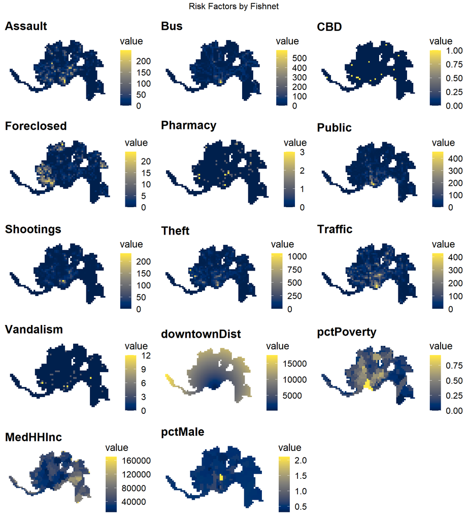

```r
vars_net <-
  rbind(Pharm, Traffic, Public, bus, cbd, Foreclosed, Shootings, Assaults, Theft, Vandalism) %>%
  st_join(., fishnet, join=st_within) %>%
  st_drop_geometry() %>%
  group_by(uniqueID, Legend) %>%
  summarize(count = n()) %>%
  full_join(fishnet) %>%
  spread(Legend, count, fill=0) %>%
  st_sf() %>%
  dplyr::select(-`<NA>`)%>%
  na.omit() %>%
  ungroup()

downtownPoint <-
  filter(Neighborhoods, SNA_NAME == "Downtown") %>%
  st_centroid()

vars_net$downtownDist =
  st_distance(st_centroid(vars_net),downtownPoint) %>%
  as.numeric()

vars_net <-
  st_centroid(vars_net) %>%
  st_join(dplyr::select(tracts18, pctPoverty)) %>%
  st_join(dplyr::select(tracts18, MedHHInc)) %>%
  st_join(dplyr::select(tracts18, pctMale)) %>%
  st_drop_geometry() %>%
  left_join(dplyr::select(vars_net, geometry, uniqueID)) %>%
  st_sf() %>%
  na.omit()

vars_net.long <-
  gather(vars_net, Variable, value, -geometry, -uniqueID)

vars <- unique(vars_net.long$Variable)
mapList <- list()

for(i in vars){
  mapList[[i]] <-
    ggplot() +
    geom_sf(data = filter(vars_net.long, Variable == i), aes(fill=value), colour=NA) +
    scale_fill_viridis(option = "cividis") +
    labs(title=i) +
    theme_map()}

do.call(grid.arrange,c(mapList, ncol=3, top="Risk Factors by Fishnet"))
```

The next step includes feature engineering. For these variables, the nearest neighbor function was used to calculate ‘average nearest neighbor distance’ from each heroin opioid overdose to its k nearest neighbor for each variable. For example, k is equal to five in pharmacies, meaning that the nearest neighbor function is calculating the average nearest distance to its five nearest neighbors from each pharmacy. The nearest neighbor function works because it first creates a matrix of distances from each point k to each heroin overdose. The matrix is then converted to a data frame, and a unique field is created representing each point distance. The data is then converted from wide to long and orders the data by ascending distance. Finally, the mean average distance is calculated using the summarized function and calculates the mean average neighbor distances. Note that this is not the first time feature engineering was done so far.

```r
function(measureFrom,measureTo,k) {
  measureFrom_Matrix <-
    as.matrix(measureFrom)
  measureTo_Matrix <-
    as.matrix(measureTo)
  nn <-
    get.knnx(measureTo, measureFrom, k)$nn.dist
  output <-
    as.data.frame(nn) %>%
    rownames_to_column(var = "thisPoint") %>%
    gather(points, point_distance, V1:ncol(.)) %>%
    arrange(as.numeric(thisPoint)) %>%
    group_by(thisPoint) %>%
    summarize(pointDistance = mean(point_distance)) %>%
    arrange(as.numeric(thisPoint)) %>%
    dplyr::select(-thisPoint) %>%
    pull()

  return(output)
}
```

```
## function(measureFrom,measureTo,k) {
##   measureFrom_Matrix <-
##     as.matrix(measureFrom)
##   measureTo_Matrix <-
##     as.matrix(measureTo)
##   nn <-
##     get.knnx(measureTo, measureFrom, k)$nn.dist
##   output <-
##     as.data.frame(nn) %>%
##     rownames_to_column(var = "thisPoint") %>%
##     gather(points, point_distance, V1:ncol(.)) %>%
##     arrange(as.numeric(thisPoint)) %>%
##     group_by(thisPoint) %>%
##     summarize(pointDistance = mean(point_distance)) %>%
##     arrange(as.numeric(thisPoint)) %>%
##     dplyr::select(-thisPoint) %>%
##     pull()
##
##   return(output)
## }
```

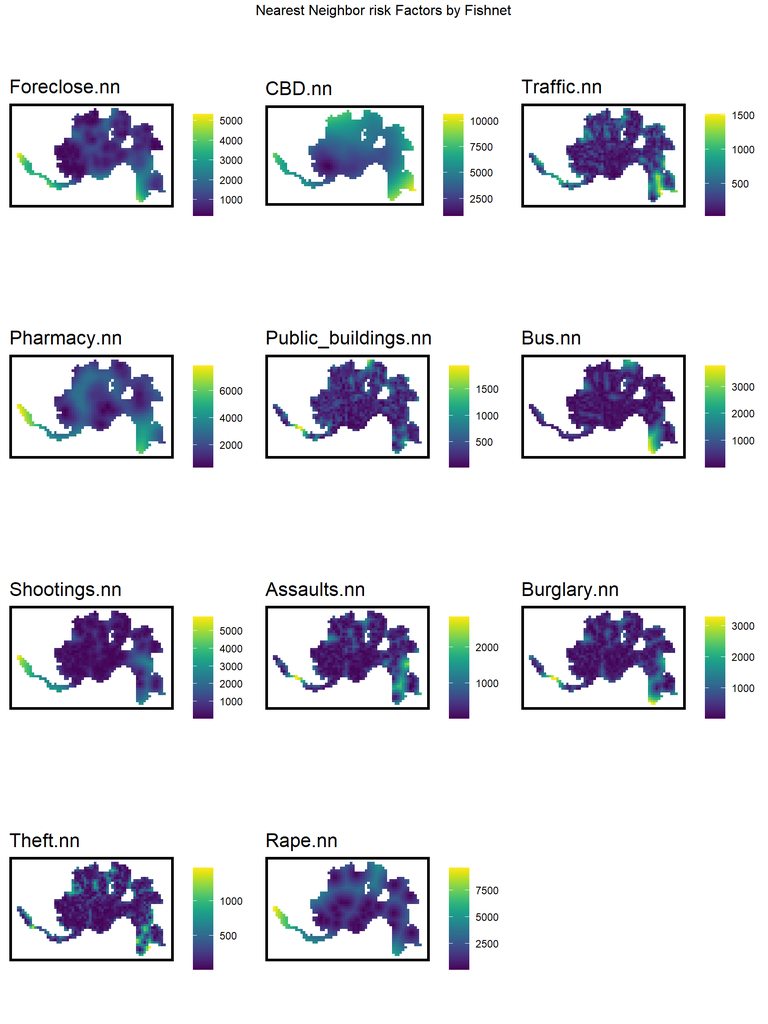

```r
ForeclosedC <- st_coordinates(Foreclosed)%>%
  na.omit()

CBDC <- st_coordinates(cbd)%>%
  na.omit()

TrafficC <- st_coordinates(Traffic)%>%
  na.omit()

BusC <- st_coordinates(bus)%>%
  na.omit()

PublicC <- st_coordinates(Public)%>%
  na.omit()

ShootingsC <- st_coordinates(Shootings)%>%
  na.omit()


PharmC <- st_coordinates(Pharm)%>%
  na.omit()

AssaultC <- st_coordinates(Assaults)%>%
  na.omit()

BurglaryC <- st_coordinates(Burglary)%>%
  na.omit()

TheftC <- st_coordinates(Theft)%>%
  na.omit()

VC <- st_coordinates(Vandalism)%>%
  na.omit()


#Nearest Neighbor

st_c <- st_coordinates
st_coid <- st_centroid

vars_net <-
  vars_net %>%
  mutate(
    Foreclose.nn =
      nn_function(st_c(st_coid(vars_net)), ForeclosedC,20),
    CBD.nn =
      nn_function(st_c(st_coid(vars_net)), CBDC, 4),
    Traffic.nn =
      nn_function(st_c(st_coid(vars_net)), TrafficC,20),
    Pharmacy.nn =
      nn_function(st_c(st_coid(vars_net)), PharmC,5),
    Public_buildings.nn =
      nn_function(st_c(st_coid(vars_net)), PublicC,10),
    Bus.nn =
      nn_function(st_c(st_coid(vars_net)), BusC,10),
    Shootings.nn =
      nn_function(st_c(st_coid(vars_net)), ShootingsC, 5),
    Assaults.nn =
      nn_function(st_c(st_coid(vars_net)), AssaultC, 5),
    Burglary.nn =
      nn_function(st_c(st_coid(vars_net)), BurglaryC, 5),
    Theft.nn =
      nn_function(st_c(st_coid(vars_net)), TheftC, 5),
    Rape.nn =
      nn_function(st_c(st_coid(vars_net)), VC, 4))




vars_net.long.nn <-
  dplyr::select(vars_net, ends_with(".nn")) %>%
  gather(Variable, value, -geometry)

vars <- unique(vars_net.long.nn$Variable)
mapList <- list()

for(i in vars){
  mapList[[i]] <-
    ggplot() +
    geom_sf(data = filter(vars_net.long.nn, Variable == i), aes(fill=value), colour=NA) +
    scale_fill_viridis(name="") +
    labs(title=i) +
    mapTheme()}

do.call(grid.arrange,c(mapList, ncol = 3, top = "Nearest Neighbor risk Factors by Fishnet"))
```

Next, the data was feature engineered to account for neighborhoods. The neighborhood shapefile is spatially joined to the final_net using grid cell centroids. The st_drop_geometry and left_join operations then drop the point centroid geometries, joining the result back to grid cell geometries and converting again to sf. Some grid cell centroids do not fall into a neighborhood and are removed with na.omit.

```r
# Neighborhoods

final_net <-
  left_join(Hero_net, st_drop_geometry(vars_net), by="uniqueID")

final_net1 <-
  left_join(Hero_net1, st_drop_geometry(vars_net), by="uniqueID")

final_net2 <-
  left_join(Hero_net2, st_drop_geometry(vars_net), by="uniqueID")


final_net <-
  st_centroid(final_net) %>%
  st_join(dplyr::select(Neighborhoods, SNA_NAME)) %>%
  st_drop_geometry() %>%
  left_join(dplyr::select(final_net, geometry, uniqueID)) %>%
  st_sf() %>%
  na.omit()

final_net1 <-
  st_centroid(final_net1) %>%
  st_join(dplyr::select(Neighborhoods, SNA_NAME)) %>%
  st_drop_geometry() %>%
  left_join(dplyr::select(final_net1, geometry, uniqueID)) %>%
  st_sf() %>%
  na.omit()

final_net2 <-
  st_centroid(final_net2) %>%
  st_join(dplyr::select(Neighborhoods, SNA_NAME)) %>%
  st_drop_geometry() %>%
  left_join(dplyr::select(final_net2, geometry, uniqueID)) %>%
  st_sf() %>%
  na.omit()

fishnetNH<-
  final_net%>%
  group_by(SNA_NAME)%>%
  summarise(th = sum(Theft), sh = sum(Shootings),
            tr = sum(Traffic), as = sum(Assault),
            bus = sum(Bus), pharm = sum(Pharmacy), forc = sum(Foreclosed), pub= sum(`Public`),va = sum(Vandalism), pp = mean(pctPoverty), pm = mean(pctMale))
```

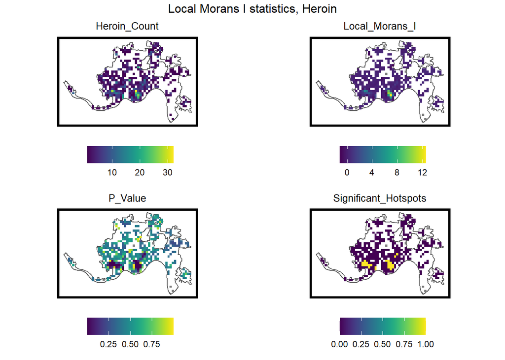

```r
final_net.nb <- poly2nb(as_Spatial(final_net), queen=TRUE)
final_net.weights <- nb2listw(final_net.nb, style="W", zero.policy=TRUE)
final_net.nb1 <- poly2nb(as_Spatial(final_net1), queen=TRUE)
final_net.weights1 <- nb2listw(final_net.nb1, style="W", zero.policy=TRUE)
final_net.nb2 <- poly2nb(as_Spatial(final_net2), queen=TRUE)
final_net.weights2 <- nb2listw(final_net.nb2, style="W", zero.policy=TRUE)

final_net.localMorans <-
  cbind(
    as.data.frame(localmoran(final_net$countOpioid, final_net.weights)),
    as.data.frame(final_net)) %>%
  st_sf() %>%
  dplyr::select(Heroin_Count = countOpioid,
                Local_Morans_I = Ii,
                P_Value = `Pr(z > 0)`) %>%
  mutate(Significant_Hotspots = ifelse(P_Value <= 0.05, 1, 0)) %>%
  gather(Variable, Value, -geometry)

vars <- unique(final_net.localMorans$Variable)
varList <- list()

for(i in vars){
  varList[[i]] <-
    ggplot() +
    geom_sf(data= cincinnati, fill = "white")+
    geom_sf(data = filter(final_net.localMorans, Variable == i),
            aes(fill = Value), colour=NA) +
    scale_fill_viridis(name="") +
    labs(title=i) +
    mapTheme() + theme(legend.position="bottom", plot.title = element_text(size = 10, hjust = 0.5))}

do.call(grid.arrange,c(varList, ncol = 2, top = "Local Morans I statistics, Heroin"))
```

Hero.isSig and Hero.isSig.dist are forms of further feature engineering to account for the spatial process. Hero.isSig indicates if a cell is part of a significant cluster. Hero.isSig is the nearest neighbor distance from each cell centroid to it’s nearest significant cluster. These variables significantly improve the results of the model.

```r
final_net1 <-
  final_net1 %>%
  mutate(Hero.isSig =
           ifelse(localmoran(final_net1$countHero,
                             final_net.weights1)[,5] <= 0.0000001, 1, 0)) %>%
  mutate(Hero.isSig.dist =
           nn_function(st_coordinates(st_centroid(final_net1)),
                       st_coordinates(st_centroid(
                         filter(final_net1, Hero.isSig == 1))), 1))

final_net2 <-
  final_net2 %>%
  mutate(Hero.isSig =
           ifelse(localmoran(final_net2$countHero,
                             final_net.weights2)[,5] <= 0.0000001, 1, 0)) %>%
  mutate(Hero.isSig.dist =
           nn_function(st_coordinates(st_centroid(final_net2)),
                       st_coordinates(st_centroid(
                         filter(final_net2, Hero.isSig == 1))), 1))
```

Correlating the variables helps determine which variables will significantly impact the model and which variables should be incorporated into the model. Generally, the higher the R squared value, the better the model. Crime variables seem to correlate well with the count of heroin overdoses, particularly the nearest neighbors of shootings, assaults, theft, and burglaries. Additionally, variables associated with downtown spatial regions such as traffic accidents, bus stops, and distance to neighborhood central business districts also seem to be strong predictors. A surprising finding is the nearest neighbor to pharmacies seem to negatively correlate to opioid overdoses, meaning heroin overdoses tend to occur closer to pharmacies. We hypothesis that pharmacies may lead to increased drug availability, leading to an increased amount of prescription drug medication in the region. Although you cannot find heroin at a pharmacy, many prescription opioid medications may lead to heroin addiction.

Additionally, each of the independent variables must be independent of one another. The second figure below depicts a correlation plot, where a value of 1 indicates the variables are positively correlated, and a value of -1 means the variables are negatively correlated. If the correlation between 2 variables is 1, or -1, only one of the variables should be included in the model. Three relationships pose a problem. Foreclosures and shootings are seemingly positively correlated. Percent Poverty and median household income seem to be negatively correlated. Finally, downtown distance and nearest neighbor to central business districts are positively correlated.

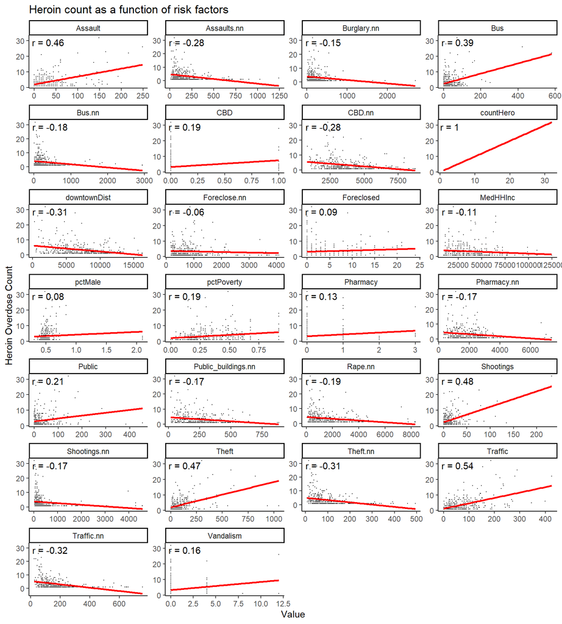

```r
correlation.long <-
  final_net%>%
  st_drop_geometry() %>%
  dplyr::select(-uniqueID, -cvID, -SNA_NAME) %>%
  gather(Variable, Value, -countOpioid)

correlation.cor <-
  correlation.long %>%
  group_by(Variable) %>%
  summarize(correlation = cor(Value, countOpioid, use = "complete.obs"))

ggplot(correlation.long, aes(Value, countOpioid)) +
  geom_point(size = 0.1) +
  geom_text(data = correlation.cor, aes(label = paste("r =", round(correlation, 2))),
            x=-Inf, y=Inf, vjust = 1.5, hjust = -.1) +
  geom_smooth(method = "lm", se = FALSE, colour = "red") +
  facet_wrap(~Variable, ncol = 4, scales = "free") +
  labs(title = "Heroin count as a function of risk factors") +
  ylab("Heroin Overdose Count")+
  theme_classic()
```

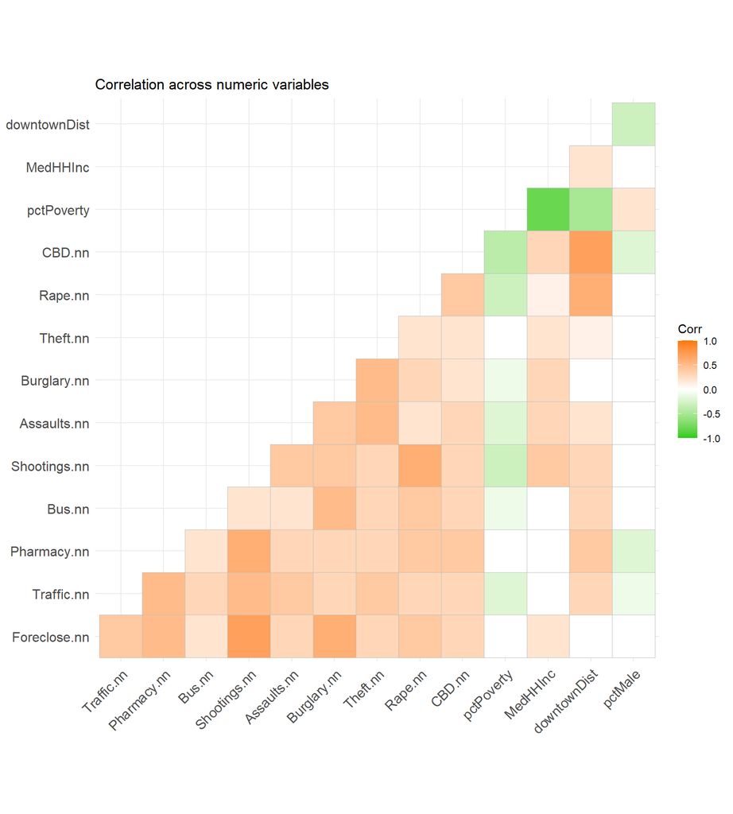

```r
final_netdrop  <- final_net %>%
  st_drop_geometry()

final_netCORR <- final_net %>%
  dplyr::select("Foreclose.nn",  "Traffic.nn",
         "Pharmacy.nn", "Bus.nn", "Shootings.nn",
         "Assaults.nn", "Burglary.nn", "Theft.nn", "Rape.nn", "CBD.nn","pctPoverty", "MedHHInc",
         "downtownDist", "pctMale")

numericVars <-
  select_if(st_drop_geometry(final_netCORR), is.numeric) %>% na.omit()

library(ggcorrplot)

ggcorrplot(
  round(cor(numericVars), 1),
  p.mat = cor_pmat(numericVars),
  colors = c("#25CB10", "white", "#FA7800"),
  type="lower",
  insig = "blank") +
  labs(title = "Correlation across numeric variables")
```

# Model

In this section, the training set, Final_net1 is validated on the test set, Final_net2. Poisson regression is based on the Poisson distribution. Poisson regression assumes the response variable Y has a Poisson distribution, and assumes a linear combination of unknown parameters can model the logarithm of its expected value. Since the count of heroin overdoses in a fishnet grid represents a Poisson distribution, it makes the most sense to use poison regression to model heroin overdoses. For a given neighborhood name, in the cross-validation function, the function assigns each grid cell not in that neighborhood to the training set, fold.train, and each cell in that neighborhood to the test set, fold.test. A model is trained from the former and used to predict the latter. The process is repeated until each neighborhood has a turn acting as a hold.

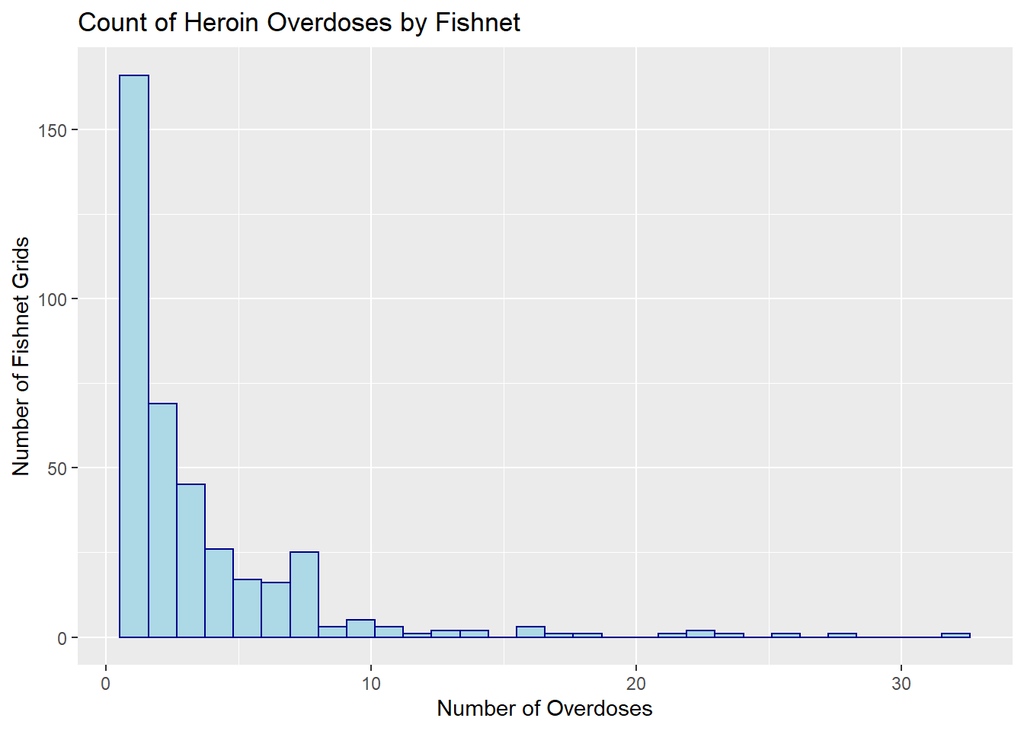

```r
ggplot(final_net, aes(x=countOpioid))+
  geom_histogram(color="darkblue", fill="lightblue")+
  labs(title = "Count of Heroin Overdoses by Fishnet", x = "Number of Overdoses", y = "Number of Fishnet Grids")
```

```r
cross <- function(train, test, id, dependentVariable, indVariables) {

  allPredictions <- data.frame()
  cvID_list <- unique(train[[id]])

  for (i in cvID_list) {

    thisFold <- i
    cat("This hold out fold is", thisFold, "\n")

    fold.train <-
      filter(train, train[[id]] != thisFold) %>% as.data.frame() %>%
      dplyr::select(id, geometry, indVariables, dependentVariable)
    fold.test  <- filter(test, test[[id]] == thisFold) %>% as.data.frame() %>%
      dplyr::select(id, geometry, indVariables, dependentVariable)

    regression <-
      glm(countOpioid ~ ., family = "poisson",
          data = fold.train %>%
            dplyr::select(-geometry, -id))

    thisPrediction <-
      mutate(fold.test, Prediction = predict(regression, fold.test, type = "response"))

    allPredictions <-
      rbind(allPredictions, thisPrediction)

  }
  return(st_sf(allPredictions))
}
```

In this section, the cross-validation function from the code above is performed. The functions are performed twice, once for k-fold regression and once for LOGO regression. K-fold regression partitions the data into equal sizes, which are known as folds. For a given fold, the model is trained on a subset of observations and predicted on a test. K-fold cross-validation takes the average goodness of fit across all k-folds. In contrast, in Leave Out Cross Validation (LOGO cross validation) each neighborhood takes a turn as a holdout. LOGO cross-validation can be very helpful when a specific neighborhood has distinct characteristics because that particular neighborhood has the opportunity to act as the holdout. Note once again that final-net1 is the training set and final_net2 is the test set.

[output not shown]

[output cut: 84 more lines]

[output not shown]

[output not shown]

[output cut: 225 more lines]

[output not shown]

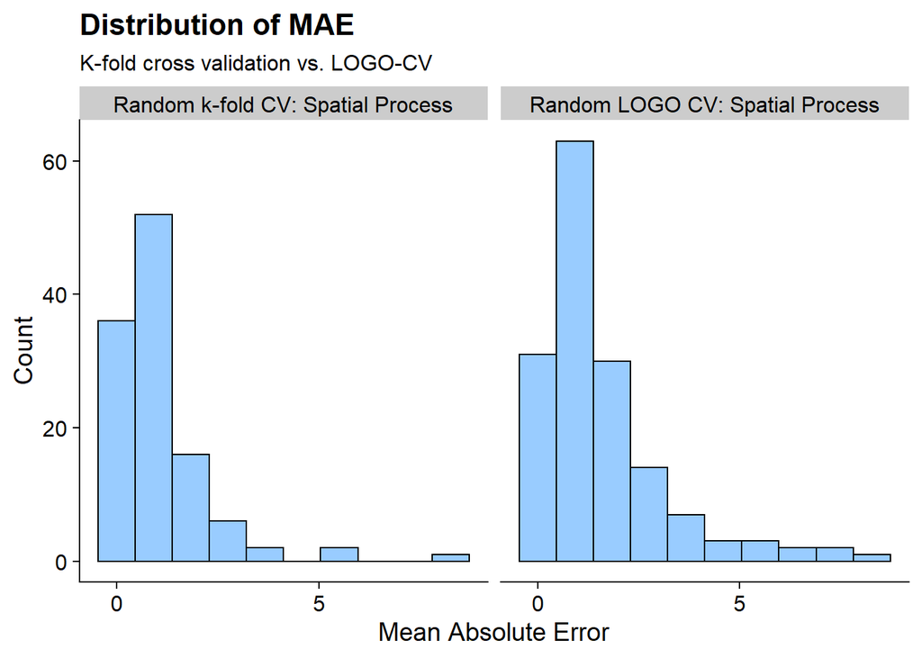

```r
reg.summary <-
  rbind(
    mutate(reg.ss.spatialCV,           Error = Prediction - countOpioid,
           Regression = "Random LOGO CV: Spatial Process"),

    mutate(reg.ss.cv,        Error = Prediction - countOpioid,
           Regression = "Random k-fold CV: Spatial Process"))


error_by_reg_and_fold <-
  reg.summary %>%
  group_by(Regression, cvID) %>%
  summarize(Mean_Error = mean(Prediction - countOpioid, na.rm = T),
            MAE = mean(abs(Mean_Error), na.rm = T),
            SD_MAE = mean(abs(Mean_Error), na.rm = T)) %>%
  ungroup()

error_by_reg_and_fold %>%
  ggplot(aes(MAE)) +
  geom_histogram(bins = 10, colour="black", fill = "#99CCFF") +
  facet_wrap(~Regression) +
  scale_x_continuous(breaks = seq(0, 30, by = 5)) +
  labs(title="Distribution of MAE", subtitle = "K-fold cross validation vs. LOGO-CV",
       x="Mean Absolute Error", y="Count") +
  theme_cowplot()
```

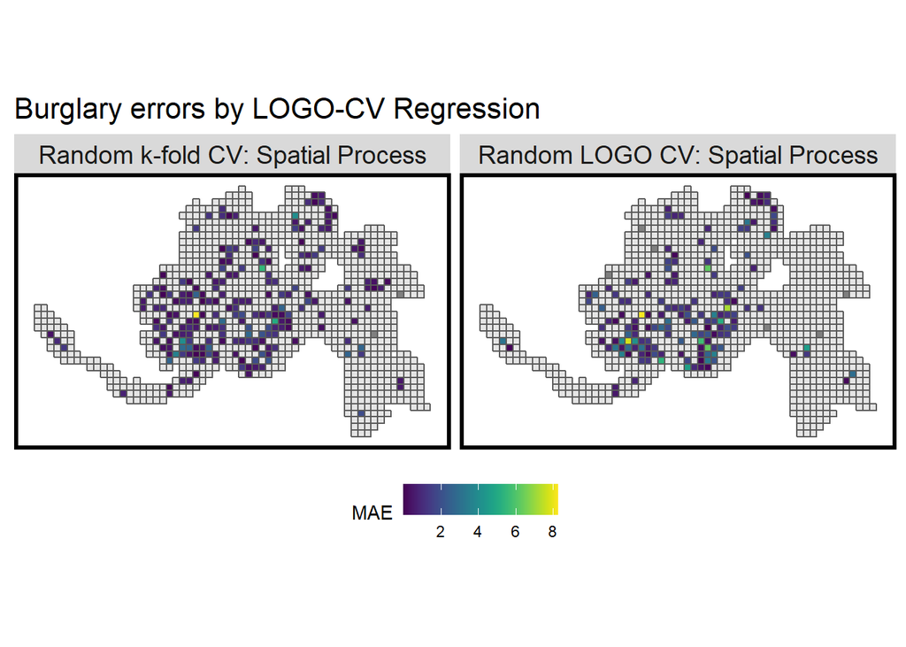

```r
error_by_reg_and_fold %>%
  ggplot() +
  geom_sf(data= fishnet)+
  geom_sf(aes(fill = MAE)) +
  facet_wrap(~Regression) +
  scale_fill_viridis() +
  labs(title = "Burglary errors by LOGO-CV Regression") +
  mapTheme() + theme(legend.position="bottom")
```

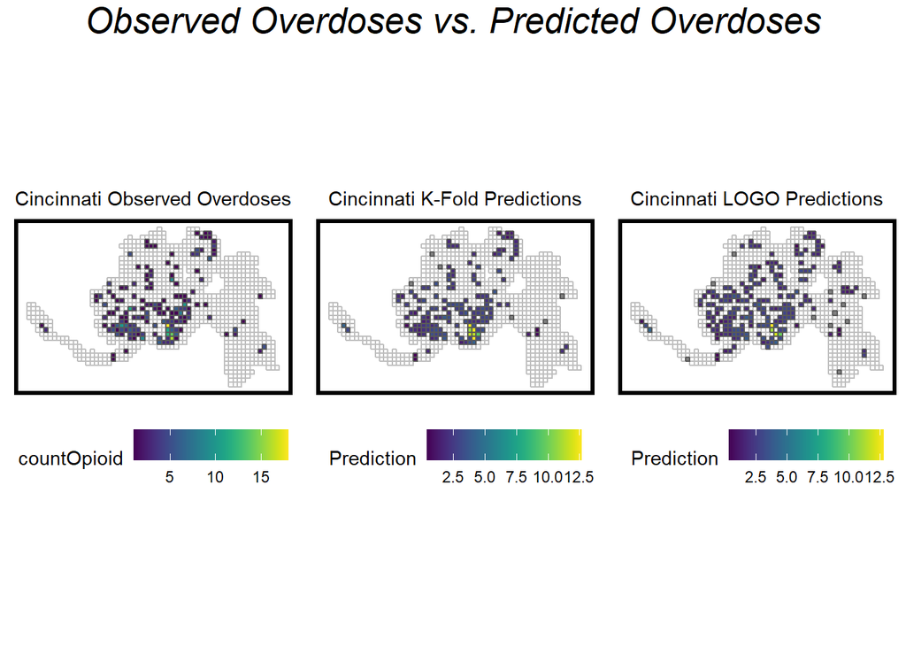

```r
grid.arrange(ncol=3,

    top=textGrob("Observed Overdoses vs. Predicted Overdoses",gp=gpar(fontsize=20,font=3)),

             ggplot() +
               geom_sf(data = fishnet, fill = "white", color = "grey")+
               geom_sf(data = reg.ss.spatialCV, aes(fill = countOpioid)) +
               scale_fill_viridis() +
               labs(title = "Cincinnati Observed Overdoses") +
               mapTheme() + theme(legend.position = "bottom", plot.title = element_text(size = 11, hjust = 0.5)),


             ggplot() +
               geom_sf(data = fishnet, fill = "white", color = "grey")+
               geom_sf(data = reg.ss.spatialCV, aes(fill = Prediction)) +
               scale_fill_viridis() +
               labs(title = "Cincinnati K-Fold Predictions") +
               mapTheme() + theme(legend.position = "bottom", plot.title = element_text(size = 11, hjust = 0.5)),


             ggplot()+
               geom_sf(data = fishnet, fill = "white", color = "grey")+
               geom_sf(data = reg.ss.cv, aes(fill = Prediction))+
               scale_fill_viridis()+
               labs(title = "Cincinnati LOGO Predictions") +
               mapTheme() + theme(legend.position = "bottom", plot.title = element_text(size = 11, hjust = 0.5))
)
```

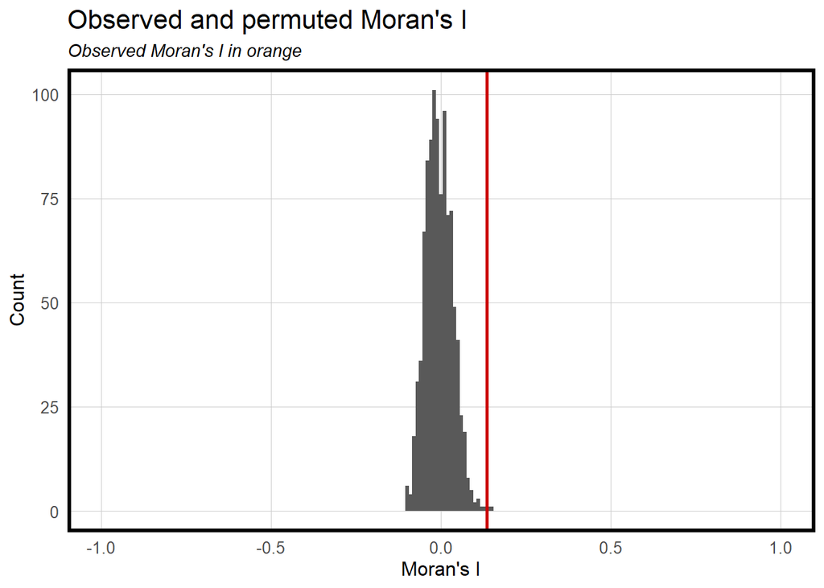

```r
reg.summary2 <- reg.summary %>% na.omit()%>%
  filter(Regression == "Random k-fold CV: Spatial Process")

coords <- st_point_on_surface(reg.summary2) %>% st_coordinates()

neighborList <- knn2nb(knearneigh(coords, 5))

spatialWeights <- nb2listw(neighborList, style="W")


#final_net1$CountHeroLag <- lag.listw(spatialWeights, final_net1$CountHero)


moranTest <- moran.mc(reg.summary2$Error,
                      spatialWeights, nsim = 999)

# That the observed I is higher then all of the 999 randomly generated I's provides visual confirmation of spatial autocorrelation
# This suggests that variation in overdoses likely related to the spatial process has been omitted from our current model.
ggplot(as.data.frame(moranTest$res[c(1:999)]), aes(moranTest$res[c(1:999)])) +
  geom_histogram(binwidth = 0.01) +
  geom_vline(aes(xintercept = moranTest$statistic), colour = "#CC0000",size=1) +
  scale_x_continuous(limits = c(-1, 1)) +
  labs(title="Observed and permuted Moran's I",
       subtitle= "Observed Moran's I in orange",
       x="Moran's I",
       y="Count") +
  plotTheme()
```

```r
tracts <-
  get_acs(geography = "tract", variables = c("B01001_001E","B01001A_001E",
                                             "B06012_002E"),
          year = 2016, state=39, county=061, geometry=T) %>%
  st_transform('ESRI:102323')  %>%
  dplyr::select(variable, estimate, GEOID) %>%
  spread(variable, estimate) %>%
  rename(TotalPop = B01001_001,
         NumberWhites = B01001A_001,
         Poverty = B06012_002) %>%
  mutate(percentWhite = NumberWhites / TotalPop,
         percentPoverty = Poverty / TotalPop,
         raceContext = ifelse(percentWhite > .5, "Majority_White", "Majority_Non_White"),
          PovertyContext = ifelse(percentPoverty > .25, "Greater than 1/4 in Poverty",
                                  "Less than 1/4 in Poverty")) %>%
  .[Neighborhoods,]
reg.summary %>%
    st_centroid() %>%
    st_join(tracts) %>%
    na.omit() %>%
      st_drop_geometry() %>%
      group_by(Regression, raceContext) %>%
      summarize(mean.Error = mean(Error, na.rm = T)) %>%
      spread(raceContext, mean.Error) %>%
      kable(caption = "Mean Error by neighborhood racial context") %>%
        kable_styling("striped", full_width = F)
```

Mean Error by neighborhood racial context

| Regression | Majority_Non_White | Majority_White |
| --- | --- | --- |
| Random k-fold CV: Spatial Process | -0.0293403 | -0.3747827 |
| Random LOGO CV: Spatial Process | -0.1351355 | -0.6088685 |

```r
reg.summary %>%
    st_centroid() %>%
    st_join(tracts) %>%
    na.omit() %>%
      st_drop_geometry() %>%
      group_by(Regression, PovertyContext) %>%
      summarize(mean.Error = mean(Error, na.rm = T)) %>%
      spread(PovertyContext, mean.Error) %>%
      kable(caption = "Mean Error by neighborhood Poverty context") %>%
        kable_styling("striped", full_width = F)
```

Mean Error by neighborhood Poverty context

| Regression | Greater than 1/4 in Poverty | Less than 1/4 in Poverty |
| --- | --- | --- |
| Random k-fold CV: Spatial Process | -0.2966697 | -0.0194306 |
| Random LOGO CV: Spatial Process | -0.4188167 | -0.2565257 |

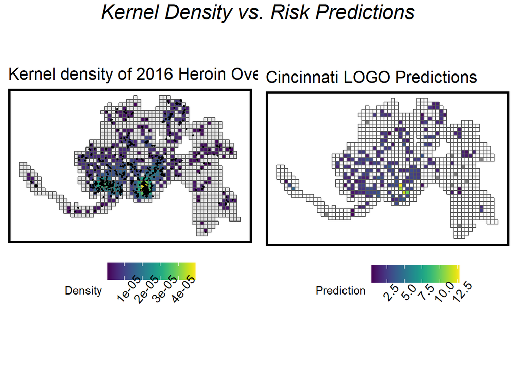

```r
burg_ppp <- as.ppp(st_coordinates(Hero), W = st_bbox(final_net))
burg_KD <- spatstat::density.ppp(burg_ppp, 574)

KD <-
  burg_KD%>%
  as.data.frame(burg_KD) %>%
  st_as_sf(coords = c("x", "y"), crs = st_crs(final_net)) %>%
  aggregate(., final_net, mean)

grid.arrange(ncol = 2,
             top=textGrob("Kernel Density vs. Risk Predictions",gp=gpar(fontsize=20,font=3)),
  ggplot() +
  geom_sf(data = fishnet)+
  geom_sf(data = KD, aes(fill=value)) +
  geom_sf(data = sample_n(Hero, 574), size = .5) +
  scale_fill_viridis(name = "Density") +
  labs(title = "Kernel density of 2016 Heroin Overdoses") +

  mapTheme() + theme(legend.position= "bottom", legend.text = element_text(angle = 50, size = 12)),

ggplot()+
               geom_sf(data = fishnet, fill = "white")+
               geom_sf(data = reg.ss.cv, aes(fill = Prediction))+
               scale_fill_viridis()+
               labs(title = "Cincinnati LOGO Predictions") +
               mapTheme() + theme(legend.position= "bottom", legend.text = element_text(angle = 50, size = 12)))
```

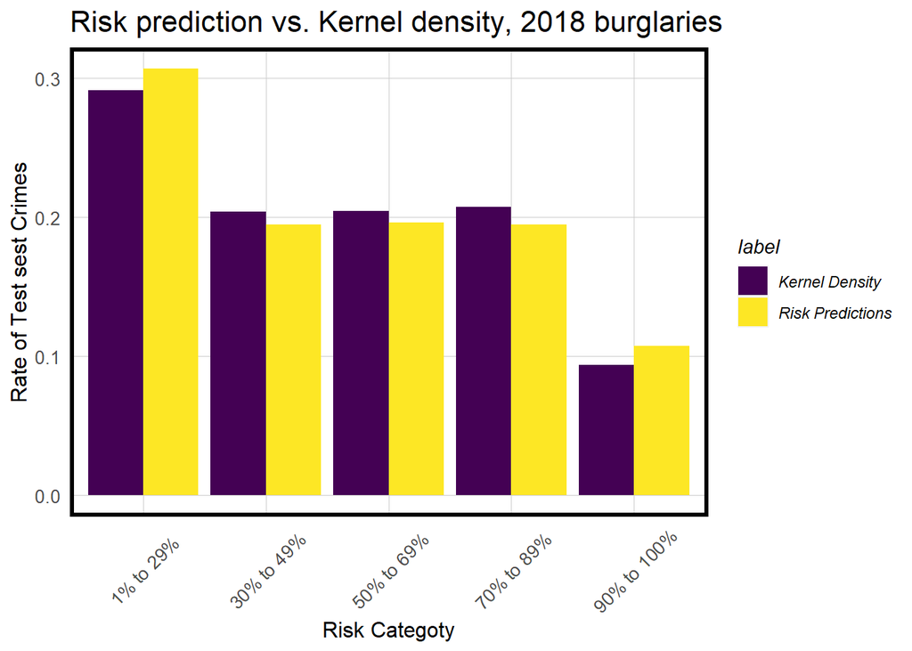

```r
# Mutating kernel density Output

burg_KDE_sf <- as.data.frame(burg_KD) %>%
  st_as_sf(coords = c("x", "y"), crs = st_crs(final_net)) %>%
  aggregate(., final_net, mean) %>%
  mutate(label = "Kernel Density",
         Risk_Category = ntile(value, 100),
         Risk_Category = case_when(
           Risk_Category >= 90 ~ "90% to 100%",
           Risk_Category >= 70 & Risk_Category <= 89 ~ "70% to 89%",
           Risk_Category >= 50 & Risk_Category <= 69 ~ "50% to 69%",
           Risk_Category >= 30 & Risk_Category <= 49 ~ "30% to 49%",
           Risk_Category >= 1 & Risk_Category <= 29 ~ "1% to 29%")) %>%
  cbind(
    aggregate(
      dplyr::select(Hero_net) %>% mutate(COUNT = 1), ., sum) %>%
      mutate(COUNT = replace_na(COUNT, 0))) %>%
  dplyr::select(label, Risk_Category, COUNT)



# Mutating Kernel Density Output
burg_risk_sf <-
  filter(reg.summary, Regression == "Random k-fold CV: Spatial Process") %>%
  mutate(label = "Risk Predictions",
         Risk_Category = ntile(Prediction, 100),
         Risk_Category = case_when(
           Risk_Category >= 90 ~ "90% to 100%",
           Risk_Category >= 70 & Risk_Category <= 89 ~ "70% to 89%",
           Risk_Category >= 50 & Risk_Category <= 69 ~ "50% to 69%",
           Risk_Category >= 30 & Risk_Category <= 49 ~ "30% to 49%",
           Risk_Category >= 1 & Risk_Category <= 29 ~ "1% to 29%")) %>%
  cbind(
    aggregate(
      dplyr::select(Hero_net) %>% mutate(COUNT = 1), ., sum) %>%
      mutate(COUNT = replace_na(COUNT, 0))) %>%
  dplyr::select(label,Risk_Category, COUNT)

rbind(burg_KDE_sf, burg_risk_sf) %>%
  st_set_geometry(NULL) %>% na.omit() %>%
  gather(Variable, Value, -label, -Risk_Category) %>%
  group_by(label, Risk_Category) %>%
  summarize(countOpioid = sum(Value)) %>%
  ungroup() %>%
  group_by(label) %>%
  mutate(Rate_of_test_set_crimes = countOpioid / sum(countOpioid)) %>%
  ggplot(aes(Risk_Category,Rate_of_test_set_crimes)) +
  geom_bar(aes(fill=label), position="dodge", stat="identity") +
  scale_fill_viridis(discrete = TRUE) +
  labs(title = "Risk prediction vs. Kernel density, 2018 burglaries",
       x= "Risk Categoty", y = "Rate of Test sest Crimes") +
  plotTheme() + theme(axis.text.x = element_text(angle = 45, vjust = 0.5))
```

# Use Case

Now that we have the predictions for the model, we can begin looking at where to recommend EMS services and rehab/ addiction support centers. The location of EMS services is essential in creating a faster response time to prevent opioid deaths. In contrast, community facilities and rehab centers ensure that those struggling with opioid addiction get the help they need. For those who have defeated heroin addiction, these resources are essential to avoid a relapse. A map of these services is located below.

```r
firehouses <-
  st_read("https://opendata.arcgis.com/datasets/a6f043d181f94e37a274975a3718b7af_16.geojson")%>%
  st_transform('ESRI:102323')%>%
  mutate(Building = "Firehouse") %>%
  dplyr::select("ADDRESS", "Building")
hospitals <-
  st_read("https://opendata.arcgis.com/datasets/0baa0cdf409e46e1800a6f08081bd9f7_1.geojson")%>%
  st_transform('ESRI:102323')%>%
  mutate(Building = "Hospital")%>%
  dplyr::select("ADDRESS", "Building")
rehab <-
  st_read("C:/Users/Tristan/Desktop/Penn/MUSA508 - Public Policy Analysis/final/rehab_Geocoded.shp")%>%
  st_transform('ESRI:102323')%>%
  mutate(ADDRESS = Match_addr, Building = "Rehab and Support Centers")%>%
  dplyr::select("ADDRESS", "Building")
```

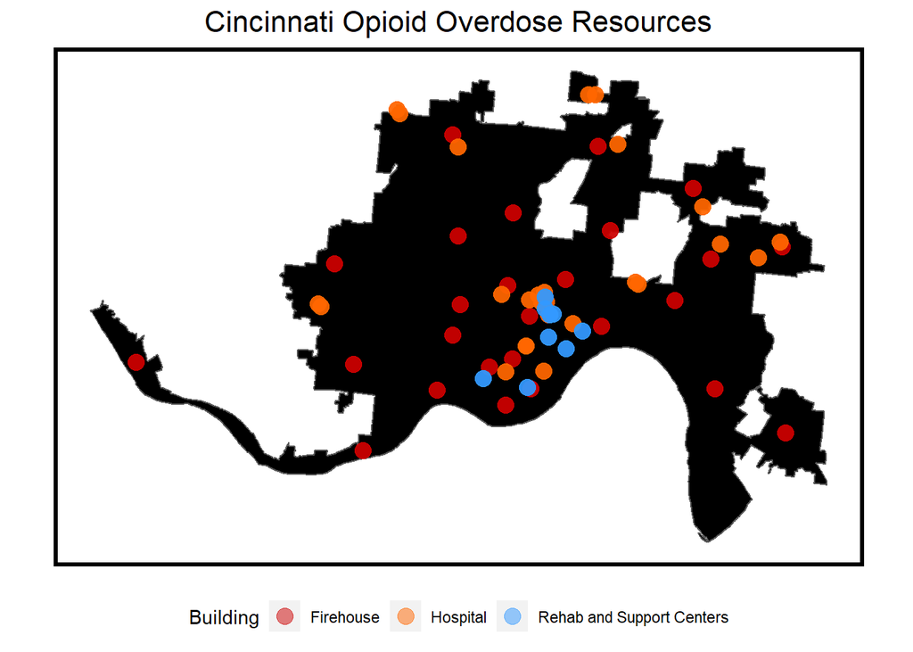

```r
narcanlocations <- rbind(hospitals, firehouses, rehab ) %>%
  st_intersection(cincinnati)

ggplot()+
  geom_sf(data = cincinnati, fill = "black")+
  geom_sf(data = narcanlocations, aes( color = Building), size = 4, alpha = 0.5) +
  scale_color_manual(values=c("#CC0000", "#FF6600", "#3399FF"))+
  labs( title = "Cincinnati Opioid Overdose Resources")+
  mapTheme()+ theme(legend.position = "bottom", plot.title = element_text(hjust = 0.5))
```

```r
narcanlocations_buffer <- st_buffer(narcanlocations, 600, endCapStyle = "SQUARE") %>%
  summarize()

highpredictgrids <- subset(reg.ss.spatialCV, Prediction >= 4)

highpredictgrids_reduced <- st_difference(highpredictgrids, narcanlocations_buffer)
highpredictgrids_reduced <-
  highpredictgrids_reduced%>%
  mutate(area = st_area(highpredictgrids_reduced))%>%
  summarise(area = sum(area))

narcanlocations_cincy <- st_union(narcanlocations, cincinnati)

highpredictgrids <- subset(reg.ss.spatialCV, Prediction >= 4)

highpredictgrids_reduced <- st_difference(highpredictgrids, narcanlocations_buffer)

 highpredictgrids_reduced %>%
   mutate(area = st_area(highpredictgrids_reduced))%>%
   summarise(area = sum(area))
```

```
## Simple feature collection with 1 feature and 1 field
## geometry type:  MULTIPOLYGON
## dimension:      XY
## bbox:           xmin: 425229.6 ymin: 123568.3 xmax: 426229.6 ymax: 125568.3
## projected CRS:  NAD_1983_HARN_StatePlane_Ohio_South_FIPS_3402
##             area                       geometry
## 1 207499.4 [m^2] MULTIPOLYGON (((426229.6 12...
```

This section analyzes where to locate EMS services. Using the original heroin data collected, we look specifically at the time difference between the dispatch time and the arrival time. According to the CDC, it is recommended that EMS services arrive in under 6 minutes for overdose cases to reduce death risk significantly. Consequently, EMS services must be fast and readily available. For this analysis, we looked at high-risk areas based on the model (> 6 overdoses in 3 months) and regions with a response time greater than 6 minutes. The result yielded two undeserved fishnet grids. We identified these regions and created a 2000 meter buffer for each fishnet grid. Since these buffers intersected, we took the intersecting area and determined where EMS services are best placed in Cincinnati. Placing an EMS service within the intersecting buffer would allow for better use of city resources so that both regions can both be served within one location. It is important to note that both fishnet grids identified as having slow EMS delay times and a high risk of a heroin overdose are near hospitals and fire stations. We interpret this as that although there are nearby EMS services, the EMS services provided do not meet the current demand. Therefore, although resources already exist in the downtown area, we recommend that more EMS services be placed in the identified region to best limit heroin overdoses. Finally, we identified vacancies with this region where EMS services can potentially be placed. That said, Cincinnati does an excellent job overall in providing fast EMS response times.

```r
ambulance <-
  Hero%>%
  filter(grepl("arrive", arrival_time_primary_unit)) %>%
  filter(grepl("dispatch", dispatch_time_primary_unit))%>%
  mutate(X = as.numeric(longitude_x),Y = as.numeric(latitude_x))%>%
  dplyr::select("X", "Y", "event_number")%>%
  na.omit()%>%
  st_as_sf(coords = c("X", "Y"), crs = 4326, agr = "constant")%>%
  st_transform('ESRI:102323')%>%
  left_join(df, by = "event_number")


ambulance <-
  Hero %>%
  mutate(arrivalhour = floor_date(ymd_hms(arrival_time_primary_unit), unit = "minute"),
         dispatchhour = floor_date(ymd_hms(dispatch_time_primary_unit), unit = "minute"))

#number of minutes of delay for each incident
ambulance$delay <-((ambulance$arrivalhour - ambulance$dispatchhour)/60)


ambulance_net <-
  Hero %>%
  mutate(delay = ambulance$delay) %>%
  aggregate(., fishnet, mean) %>%
  mutate(countHero = replace_na(delay, 0),
         uniqueID = rownames(.),
         cvID = sample(round(nrow(fishnet) / 24), size=nrow(fishnet), replace = TRUE))
slowreponsegrids <- subset(ambulance_net, delay >= 6)
```

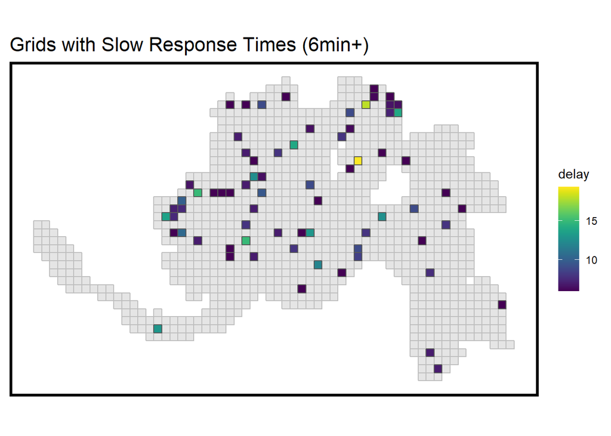

```r
ambulance <-
  Hero%>%
  filter(grepl("arrive", arrival_time_primary_unit)) %>%
  filter(grepl("dispatch", dispatch_time_primary_unit))%>%
  mutate(X = as.numeric(longitude_x),Y = as.numeric(latitude_x))%>%
  dplyr::select("X", "Y", "event_number")%>%
  na.omit()%>%
  st_as_sf(coords = c("X", "Y"), crs = 4326, agr = "constant")%>%
  st_transform('ESRI:102323')%>%
  left_join(df, by = "event_number")


ambulance <-
  Hero %>%
  mutate(arrivalhour = floor_date(ymd_hms(arrival_time_primary_unit), unit = "minute"),
         dispatchhour = floor_date(ymd_hms(dispatch_time_primary_unit), unit = "minute"))

#number of minutes of delay for each incident
ambulance$delay <-((ambulance$arrivalhour - ambulance$dispatchhour)/60)


ambulance_net <-
  Hero %>%
  mutate(delay = ambulance$delay) %>%
  aggregate(., fishnet, mean) %>%
  mutate(countHero = replace_na(delay, 0),
         uniqueID = rownames(.),
         cvID = sample(round(nrow(fishnet) / 24), size=nrow(fishnet), replace = TRUE))%>%
  filter(delay >= 5)

ggplot()+
  geom_sf(data = fishnet, color = "grey")+
  geom_sf(data = slowreponsegrids, aes(fill = delay))+
               scale_fill_viridis() +
               labs(title = "Grids with Slow Response Times (6min+)")+
               mapTheme()
```

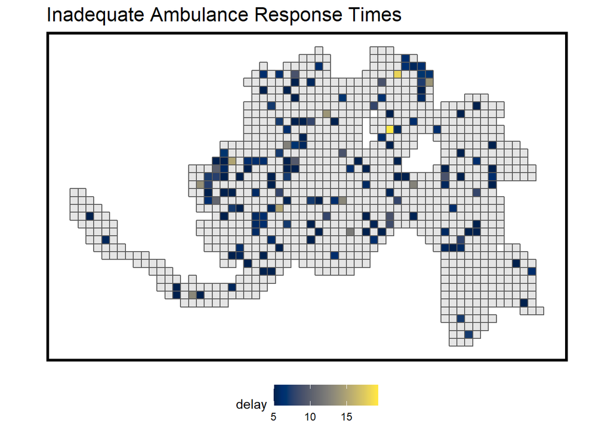

```r
ggplot()+
  geom_sf(data = fishnet)+
  geom_sf(data = ambulance_net)+
  geom_sf(data = ambulance_net, aes(fill = delay))+
  scale_fill_viridis(option = "cividis") +
  labs(title = "Inadequate Ambulance Response Times",
       Subtitle = "Greater than 4 minutes",
       color = "Delay")+
  mapTheme()+ theme(legend.position = "bottom")
```

```r
ambulance_net_pred <-
  ambulance_net%>%
  st_join(reg.ss.spatialCV)%>%
  filter(Prediction >= 6& delay >= 6)

ambulance_net_buf <-
  ambulance_net_pred%>%
  st_buffer(2000)

buf1 <- ambulance_net_buf%>%
  filter(uniqueID == 308)

buf2 <- ambulance_net_buf%>%
  filter(uniqueID == 196)


intersection <- st_intersection(buf1, buf2)

Vacant <-
  st_read("C:/Users/Tristan/Desktop/Penn/MUSA508 - Public Policy Analysis/final/vacantfootprints/vacantparcels.shp")%>%
  st_transform('ESRI:102323')%>%
  st_centroid()
```

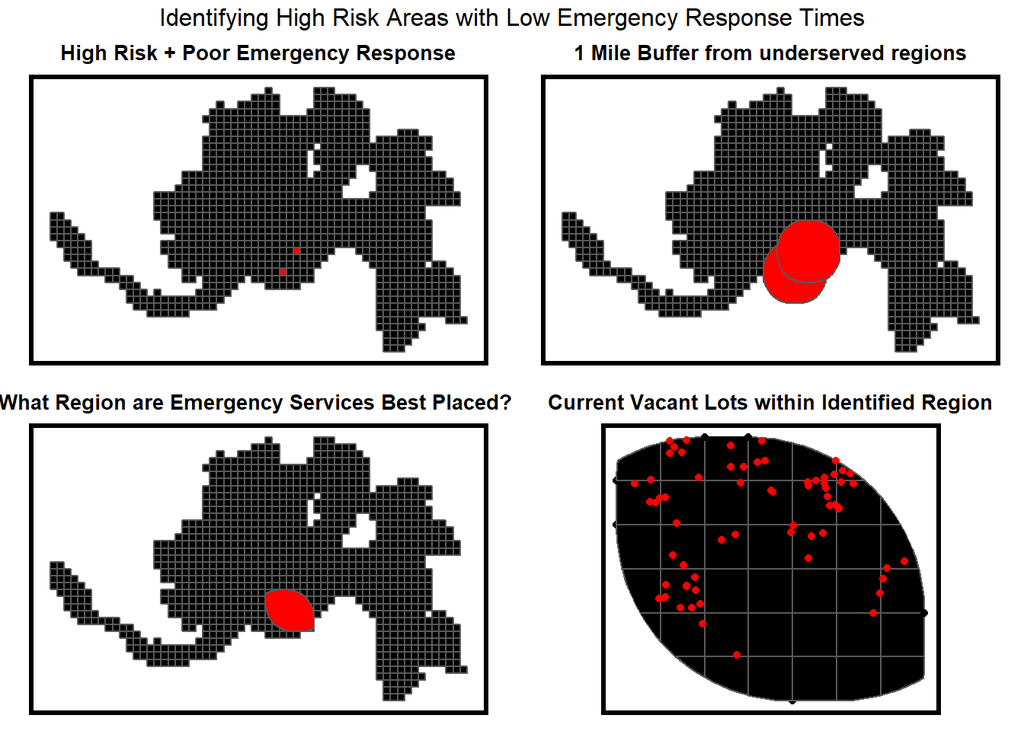

```r
fishnet_intersection = st_intersection(fishnet, intersection)

Vacant_intersection = st_intersection(Vacant, fishnet_intersection)

grid.arrange(ncol=2,
             top=("Identifying High Risk Areas with Low Emergency Response Times"),
             #top=textGrob("Identifying High Risk Areas with Low Emergency Response Times",gp=gpar(fontsize=15,font=3)),
             ggplot(cex.lab=1.5)+
               geom_sf(data = fishnet, fill ="black")+
               geom_sf(data = ambulance_net_pred, fill = "red")+
               labs(title = "High Risk + Poor Emergency Response",
                    Subtitle = "Greater than 4 minutes")+
               mapTheme()+ theme(legend.position = "bottom", plot.title = element_text(size = 10, hjust = 0.5, face = "bold")),

             ggplot(cex.lab=20)+
               geom_sf(data = fishnet, fill = "black")+
               geom_sf(data = ambulance_net_buf, fill = "red")+
               labs(title = "1 Mile Buffer from underserved regions",
                    Subtitle = "Greater than 4 minutes")+
               mapTheme()+ theme(legend.position = "bottom", plot.title = element_text(size = 10, hjust = 0.5, face = "bold")),

             ggplot(cex.lab=1.5)+
               geom_sf(data = fishnet, fill = "black")+
               geom_sf(data = intersection, fill = "red")+
               labs(title = "What Region are Emergency Services Best Placed? ",
                    Subtitle = "Greater than 4 minutes")+
               mapTheme()+ theme(legend.position = "bottom", plot.title = element_text(size = 10, hjust = 0.5, face = "bold")),


             ggplot(cex.lab=1.5)+
               geom_sf(data = intersection, fill = "white")+
               geom_sf(data = fishnet_intersection, fill = "black")+
               geom_sf(data = Vacant_intersection, color = "red")+
               labs(title = "Current Vacant Lots within Identified Region",
                    Subtitle = "Greater than 4 minutes")+
               mapTheme()+ theme(legend.position = "bottom", plot.title = element_text(size = 10, hjust = 0.5, face = "bold")))
```

```r
Vacant_inter<-
  Vacant_intersection%>%
  rename(Address = OWNAD1, Lot_Owner = OWNNM1)

# Vacant_inter%>%
#   st_drop_geometry()%>%
#   dplyr::select("Address", "Lot_Owner")%>%
#   kbl(caption = "Potential Lots for EMS Services")%>%
#   kable_material_dark(c("striped"))
```

Overall, Cincinnati does an excellent job in providing opioid support services. Only one fishnet grid cell has been recognized as a region of high risk of opioid overdoses and greater than 2 miles from a rehab facility or an addiction support center (within walking distance). To determine where we think support services should be located, we created a 1-mile buffer around the fishnet. We recommend a that a rehab facility locates within that buffer to best support those suffering from heroin addiction. Like before, we identified a list of vacant lots for the city to explore potentially. Unfortunately, these vacant lots are not located in a commercial zoning district. We recommend either a use variance in this region or an updated zoning code to allow rehab centers/ addiction support centers to be conditional from a city government perspective. The list of potential vacant sites is commented out in the code. To get a full list, view line 1387.

```r
rehab_buf <- st_buffer(rehab, 3200)

rehab_buf$area=1

rehab_bufdissolve <- rehab_buf %>%
  summarise(area = sum(area))

rehab_bufdissolve2 <- st_intersection(rehab_bufdissolve, cincinnati)

UnderservedRisk <-
  reg.summary%>%
  filter(Prediction >= 4, Regression == "Random k-fold CV: Spatial Process")%>%
  unique()%>%
  st_union()


UnderservedRiskerase <- st_difference(UnderservedRisk, st_union(rehab_bufdissolve2))

UnderservedRiskeraseBuff <- st_buffer(UnderservedRiskerase, 1600)%>%
  st_intersection(cincinnati)

Vacant2 <-
  st_read("C:/Users/Tristan/Desktop/Penn/MUSA508 - Public Policy Analysis/final/vacantfootprints/vacantparcels.shp")%>%
  st_transform('ESRI:102323')%>%
  st_centroid()
```

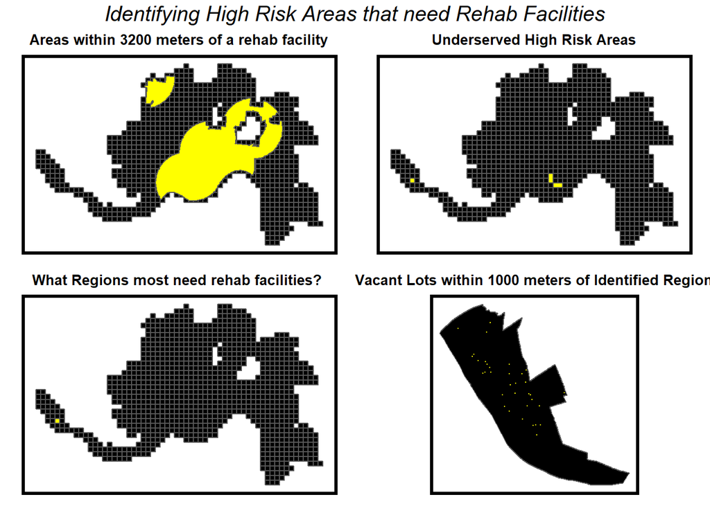

```r
vacant_underserved = st_intersection(Vacant2, UnderservedRiskeraseBuff)%>%
  st_intersection(cincinnati)%>%
  rename(Address = OWNAD1, Lot_Owner = OWNNM1)




grid.arrange(ncol=2,
             top=textGrob("Identifying High Risk Areas that need Rehab Facilities",gp=gpar(fontsize=15,font=3)),
             ggplot(cex.lab=1.5)+
               geom_sf(data = fishnet, fill ="black")+
               geom_sf(data = rehab_bufdissolve2, fill = "yellow")+
               labs(title = "Areas within 3200 meters of a rehab facility")+
               mapTheme()+ theme(legend.position = "bottom", plot.title = element_text(size = 10, hjust = 0.5, face = "bold")),

             ggplot(cex.lab=20)+
               geom_sf(data = fishnet, fill = "black")+
               geom_sf(data = UnderservedRisk, fill = "yellow")+
               labs(title = "Underserved High Risk Areas")+
               mapTheme()+ theme(legend.position = "bottom", plot.title = element_text(size = 10, hjust = 0.5, face = "bold")),

             ggplot(cex.lab=1.5)+
               geom_sf(data = fishnet, fill = "black")+
               geom_sf(data = UnderservedRiskerase, fill = "yellow")+
               labs(title = "What Regions most need rehab facilities? ")+
               mapTheme()+ theme(legend.position = "bottom", plot.title = element_text(size = 10, hjust = 0.5, face = "bold")),


             ggplot(cex.lab=1.5)+
               geom_sf(data = UnderservedRiskeraseBuff, fill = "black")+
               geom_sf(data = vacant_underserved, color = "yellow", size = .1)+
               labs(title = "Vacant Lots within 1000 meters of Identified Region")+
               mapTheme()+ theme(legend.position = "bottom", plot.title = element_text(size = 10, hjust = 0.5, face = "bold")))
```

```r
zoning <- st_read("https://opendata.arcgis.com/datasets/1dcafeb2b62d4a02b3a19ee5fc7041ce_4.geojson")%>%
  mutate(ZONE_TYPE = ifelse(ZONING == "RMX" | ZONING == "CN" | ZONING == "CC" | ZONING == "CG"| ZONING =="UM"| ZONING == "DD"| ZONING == "RF-C", "Commercial Zoning", "Not Commercial Zoning"))%>%
  st_transform('ESRI:102323')%>%
  st_intersection(UnderservedRiskeraseBuff)
```

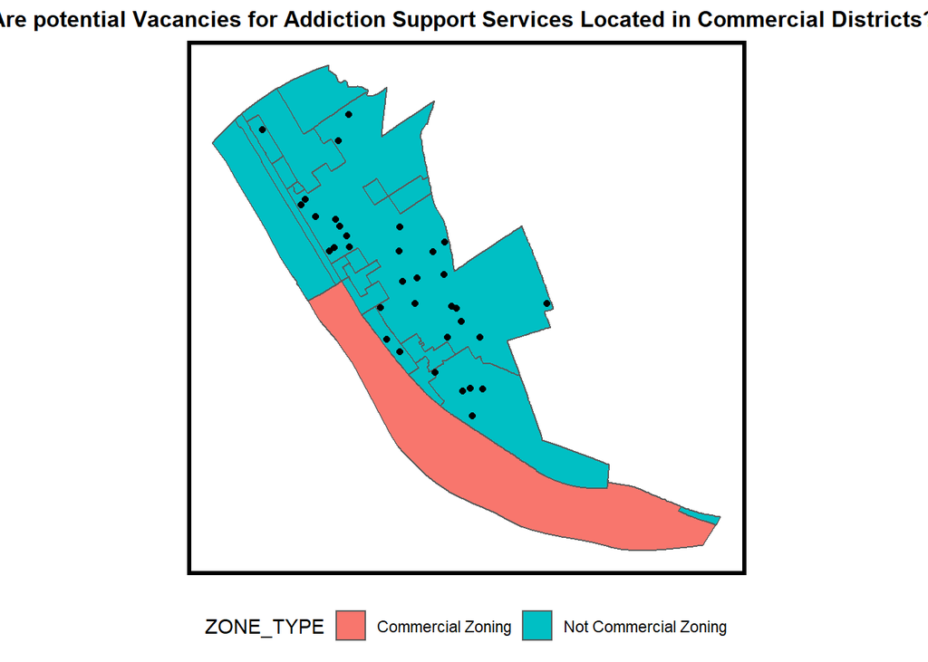

```r
ggplot()+
  geom_sf(data = zoning, aes(fill = ZONE_TYPE))+
  geom_sf(data = vacant_underserved)+
  labs(title ="Are potential Vacancies for Addiction Support Services Located in Commercial Districts? ",
       color = "Zone Type")+
  mapTheme()+ theme(plot.title = element_text(size = 12, face = "bold" , hjust = 0.5), legend.position = "bottom")
```

```r
# vacant_underserved%>%
#   st_drop_geometry()%>%
#   dplyr::select("Address", "Lot_Owner")%>%
#   kbl(caption = "Potential Lots for Rehab or Addiction Support Services")%>%
#   kable_material_dark(c("striped"))
```

# Conclusion

In summary, predicting heroin overdoses is essential so that the municipality can best allocate resources to people who will benefit the most from a solved the heroin overdose crisis. We believe that our model can be an effective tool in helping to solve the heroin overdose crisis in Cincinnati. To run our model, we created a training set and a test set utilizing 2016 data. Unfortunately, data entry was very inconsistent across time, and we could not predict on larger temporal scales. For example, 2015 had 1/3 of the number of data points, and 2017 only had 100 data points. Instead, we decided to utilize June 6-September 12th, 2016 as the training set, and September 12th- December 31st as the test set. We began by engaging in feature engineering, where we aggregated each of our variables into a fishnet grid. We also utilized feature engineering by using the nearest neighbor function and engineering our own features, such as the CBD variable. In the exploratory analysis, it became clear that larger amounts of heroin overdoses often occur near downtown regions. Consequently, we decided to import features such as bus stops and traffic accidents into the model to help account for this clustering of heroin overdoses. In the exploratory analysis, the Moran’s I also revealed that significant clustering of heroin overdoses occur in the downtown of Cincinnati. Variables that we noticed having strong correlations with the count of overdoses in each fishnet include traffic, shootings, theft, assaults, burglaries, vandalism, central business district, and foreclosures. We ensured that each of the variables is independent of one another by creating a correlation plot. Finally, we found that joining neighborhoods made a significant difference in the model.

Finally, we analyze where services in Cincinnati should be placed. We accomplish this goal by looking at both EMS services and community/ rehab centers. For EMS services, we were looking for areas where we recommend the city to locate EMS services. Specifically, we looked for fishnet grid cells where EMS delay time was high, and risk predictions were high. We identified only two fishnet grid cells, indicating that Cincinnati is already doing an excellent job at providing EMS services to high-risk heroin overdose regions. Once our area is identified, we identified vacant lots that fall within our recommend region. A similar process was repeated to identify locations for the placement of rehab centers and addiction support services. We identified only one high-risk area that was underserved, meaning that Cinncinati is overall providing necessary services to high-risk areas. Although we identified vacant regions where we believe a rehab center should be placed, we recognize that this is a challenge in this location due to the current zoning laws.

# Sources

[Ken Steif’s Book](https://www.youtube.com/watch?v=mM-kaYQsX7k)

[CDC Heroine Overdose](https://www.cdc.gov/drugoverdose/data/heroin.html)

[Cincinnati City Government Data Portal](https://data.cincinnati-oh.gov/)